# Yi DENG’s Blog

## learning, living, having fun, serving the community

# 购物篮分析（apriori先验算法）

Mar 15th, 2015 12:00 am

# 购物篮分析（Apriori关联规则算法及其R语言实现）

Yi DENG

March 15, 2015

# 引：啤酒和尿布的故事

隐约记得听过一个啤酒和尿布的故事，即超市通过分析自身客户的购物行为，发现奶爸在给小孩买尿布的同时喜欢顺便买啤酒，于是通过这种潜在的关系来优化货架摆放、组合营销策略等。

关联规则算法的主要应用是购物篮分析，是为了从大量的订单中发现商品潜在的关联。其中常用的一个算法叫Apriori先验算法。

# 主要指标与概念

关联规则的表示方法为 x => y，表示购买x商品的客户也可能购买y商品。 最常用的是支持度、置信度两个指标，当然还有其他诸如Lift等指标。

1. 支持度support: $支持度(x) = 包含x商品的订单数 / 总订单数$
2. 置信度confidence： $置信度(x=>y) = 支持度(x \cup y)/支持度(x)$

| 订单编号 | 商品 |
| --- | --- |
| 001 | 啤酒，尿布 |
| 002 | 啤酒，尿布 |
| 003 | 口红 |
| 004 | 啤酒 |

以上表4个订单的集合为例。则对于如下规则:

1. 规则：尿布=>啤酒  
   支持度（尿布=>啤酒） = 支持度(尿布$\cup$啤酒) = 2/4 = 1/2  
   置信度（尿布=>啤酒） = 2/2 = 1
2. 规则：啤酒=>尿布  
   支持度（啤酒=>尿布） = 2/4 = 1/2  
   置信度（啤酒=>尿布） = 2/3

针对上述的情况，发现（尿布=>啤酒)，(啤酒=>尿布)这两个规则的支持度相同,都是50%；但(尿布=>啤酒)的置信度水平更高,100% vs 66%。含义则是买尿布的人更可能买啤酒，但买啤酒的人未必买尿布。

至于在大数据量下如何选取关联规则，还需要针对实际情况按指标含义做选择。 支持度表示的是商品组合在整个订单集合中的出现比例。而置信度表示在商品组合中，买了前置商品的有多少会同时购买后置商品（对于尿布=>啤酒。 尿布是前置商品antecedent，啤酒是后置商品consequent）。

# R语言实现及可视化

可使用R语言的arules和arulesViz两个包实现apriori关联算法和结果可视化。

```r
library(arules)
# 原始数据
list  <- list('001'=c('beer', 'nappy'), '002'=c('beer', 'nappy'), '003'='lipstick', '004'='beer')
trData <- as(list, 'transactions')  # 转化为transaction类数据
inspect(trData)  # 查看数据情况
```

```
##   items      transactionID
## 1 {beer,
##    nappy}              001
## 2 {beer,
##    nappy}              002
## 3 {lipstick}           003
## 4 {beer}               004
```

```r
rules <- apriori(trData, parameter = list(supp = 0.1, conf =0.1))  # apriori关联算法函数调用
```

```r
inspect(rules)  # 查看输出的规则
```

```
##   lhs        rhs        support confidence     lift
## 1 {}      => {lipstick}    0.25  0.2500000 1.000000
## 2 {}      => {nappy}       0.50  0.5000000 1.000000
## 3 {}      => {beer}        0.75  0.7500000 1.000000
## 4 {nappy} => {beer}        0.50  1.0000000 1.333333
## 5 {beer}  => {nappy}       0.50  0.6666667 1.333333
```

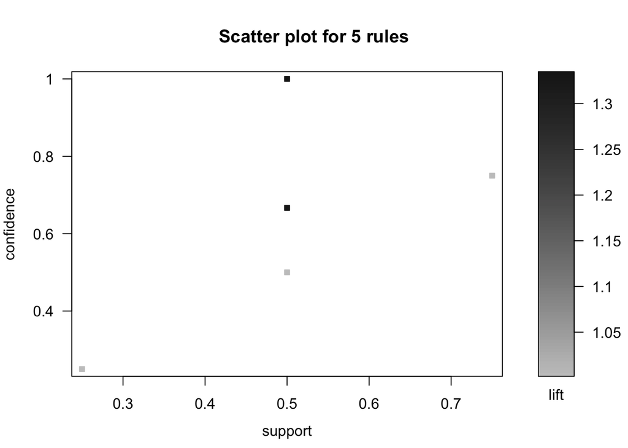

```r
library(arulesViz)  # 加载可视化包
plot(rules, method='scatterplot') # 散点图判断大量规则的支持度与置信度分布情况
```

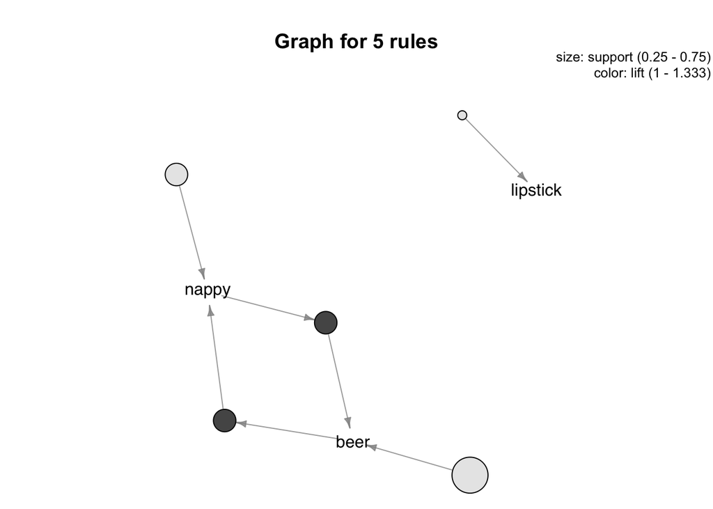

```r
plot(rules, method='graph', control = list(type='items')) # 关联图看相互关系
```

参考：  
【1】Michael Hahsler etc., *Introduction to arules*  
【2】Wikipedia, [*Association rule learning*](http://en.wikipedia.org/wiki/Association_rule_learning)  
【3】高燕, [*关联规则：R与SAS的比较*](http://cos.name/2013/02/association-rules-with-r-and-sas/)

# 衰减算法小结

Dec 28th, 2014 12:00 am

# 衰减方程（函数）小结 Decay Function Review

Yi DENG

December 28, 2014

# 衰减方程的应用

1. 推荐算法、排序算法。如果原始数据是一堆时间序列数据（如每天销售数据）。进行计算时，常见的想法是给近期的指标更大的权重（理由：客户近期购买的产品更能反映当前客户的偏好）。衰减方程用于生成对应时间的权值。
2. 库存管理。对易腐坏物品（库存），对其价值进行衰减。

# 几个有用的方程(函数)

| 类型 | 方程 | 当t=L | 备注 |
| --- | --- | --- | --- |
| 线性衰减 (linear) | $1 - t/L$ | 全衰 |  |
| 指数衰减（exponential） | $2^{-t/L}$ 也可写为 $e^{ -t/L * log(2)}$ | 半衰 | 2不是固定值，可调整 |
| 韦伯衰减（Weibull） | $e^{ -(t/L)^k * log(2)}$ | 半衰 | k为形状参数，实数。当k=1时，为指数衰减。 |

- 注：t为时间, L为生命衰减周期（常数）

以下是R计算代码和图形。就目前的了解，我更倾向使用韦伯分布作为估计，通过调整参数k，可以呈现不同的效果（根据需求，调整下降速度是先快后慢，还是先慢后快)

设  
$t = 1,2,…,54$ (一年54周)  
$L = 27$ （衰减周期为半年）  
$k_1 = 2$ （韦伯衰减k = 2）  
$k_2 = 0.5$ （韦伯衰减k = 0.5）

需要关注的是，  
1. 要计算的需求是全衰还是半衰  
2. 下降速率  
参考链接[1]中还提供了一种smooth-compact方程，可以用作全衰的计算。因为一时没查到相关资料，不确定该方程来源，在此暂不计算。

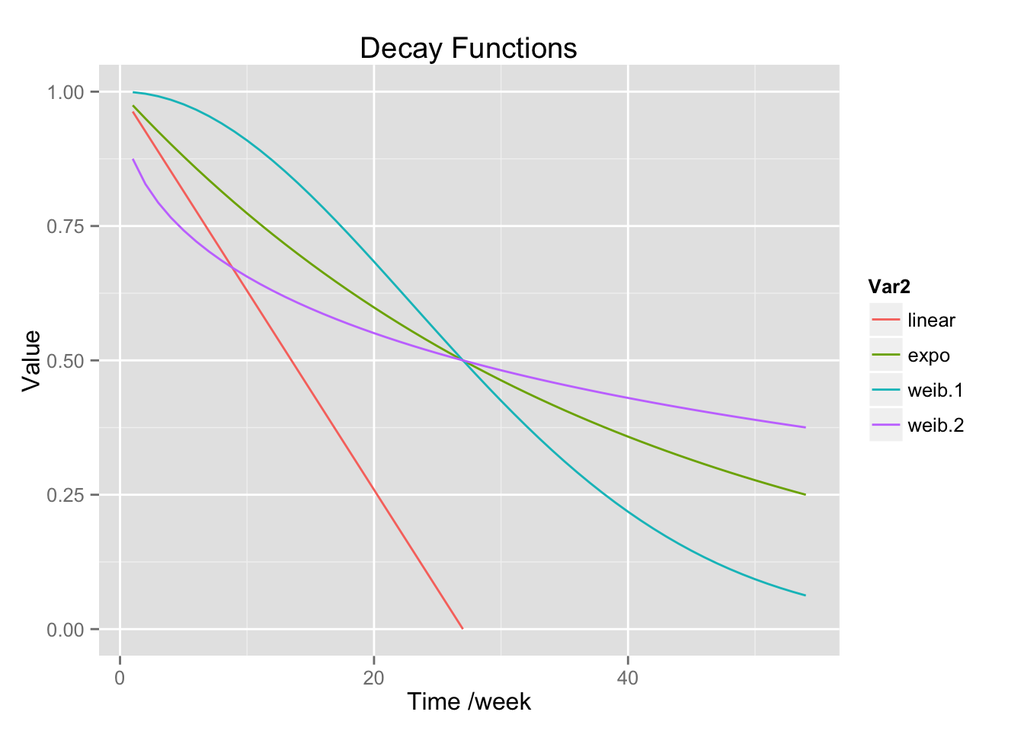

```r
# 参数设定
t <- 1:54
L <- 27
k1 <- 2
k2 <- 0.5

# 线性衰减
linear <- 1 - t/L

# 指数衰减
expo <- 2^(-t/L)

# 韦伯衰减（Weibull Decay Function）
weib.1 <- exp(-(t/L)^k1 * log(2))
weib.2 <- exp(-(t/L)^k2 * log(2))

# 画图
data <- cbind(linear, expo, weib.1, weib.2)
library(reshape2)
meltdata <- melt(data)
library(ggplot2)
ggplot(data = meltdata, ylim = 0:1,
       aes(x = Var1, y = value, color = Var2)) +
    geom_line() +
    ylim(0,1) +
    labs(title = "Decay Functions", x= "Time /week", y = "Value")
```

参考： [1]https://code.google.com/p/openmalaria/wiki/ModelDecayFunctions

Blog Archives

# 关于我 (About Me)

所在行业: B2C电商  
所在地: 深圳  
邮箱: michael.yi.deng@gmail.com  
社交: [Github](https://github.com/Yi-DENG), [LinkedIn](https://cn.linkedin.com/in/dengyichina/)

# Recent Posts

- 购物篮分析（apriori先验算法）
- 衰减算法小结